# Lab One - Exploring Table Data

## Group Members:

- Ayesh Madushanka Mahamada Kalapuwage
- Mayar Tarek Ibrahim
- Barbara Maria Teixeira Costa Peluzo

## Data Set Information

The dataset is obtained from https://archive.ics.uci.edu/ml/datasets/Estimation+of+obesity+levels+based+on+eating+habits+and+physical+condition+

There is a related article: https://reader.elsevier.com/reader/sd/pii/S2352340919306985?token=FBE9F3F02627BEC93C8C5B3D4AB21D2CFD7E1F1D5753D6E73C3D29782F8C5E15A1EFFB3D89167C60D99847BADBF46ABB&originRegion=us-east-1&originCreation=20210908201213

### 1. Businees Understanding

The data consists of 2111 instances and 17 attributes related to the physical activity, life style, and obesity.

The data consists of 2111 instances and 17 attributes related to the physical activity, life style, and obesity. Those attributes and their data type are the following:

```
A. Gender - binary
B. Age - ordinal
C. Height (meters) - interval (float)
D. Weight (kilograms) - interval (float)
E. Family history with overweight - binary
F. Frequent consumption of high caloric food (FAVC) - binary
G. Frequency of vegetables consumption (FCVC) - ordinal
H. Number of main meals (NCP) - ordinal
I. Consumption of food between meals (CAEC) - ordinal (entries will be converted to integers)
J. Smoke habit - binary
K. Daily consumption of water (CH2O) - ordinal
L. Monitoring of calories consumption (SCC) - binary
M. Frequency of physical activity during the week (FAF) - ordinal
N. Time using technological devices (TUE) - ordinal
O. Alcohol consuption (CALC) - ordinal (entries will be converted)
P. Main transportation used (MTRANS) - ordinal (entries will be converted)
Q. Obesity level - ordinal (entries will be converted)
```

#### Note:

We decided to treat MTRANS entry as ordinal because it might interfere at one's weight (specially by comparing people who walk or ride a bike with the ones who use cars as main transportation)

This study can be used to identify the risk factors that result in obesity. The results can be used by insurance companies for example to know the individuals who are subject to obesity from the life style, family history, age, and gender. People with high level of obesity tend to be in higher risk of different diseases as: cardiovascular diseases and diabetes. Similarly, this can also be the interest of physicians.

### Questions:

- How does gender affect the level of obesity?
- How does life style affect the level of obesity?
- How does age affect the level of obesity?
- How does family history with overweight affect the level of obesity?

## Data Description

```python
#Importing packages
import pandas as pd
import numpy as np
import seaborn as sns
import matplotlib
import matplotlib.pyplot as plt
import os
%matplotlib inline
import warnings
warnings.simplefilter('ignore', DeprecationWarning)
import missingno as mn
```

```python
#Reading file and checking the type of the attributes

df = pd.read_csv('ObesityDataSet_raw_and_data_sinthetic.csv')
df.info()
```

```
<class 'pandas.core.frame.DataFrame'>
RangeIndex: 2111 entries, 0 to 2110
Data columns (total 17 columns):
 #   Column                          Non-Null Count  Dtype
---  ------                          --------------  -----
 0   Gender                          2111 non-null   object
 1   Age                             2111 non-null   float64
 2   Height                          2111 non-null   float64
 3   Weight                          2111 non-null   float64
 4   family_history_with_overweight  2111 non-null   object
 5   FAVC                            2111 non-null   object
 6   FCVC                            2111 non-null   float64
 7   NCP                             2111 non-null   float64
 8   CAEC                            2111 non-null   object
 9   SMOKE                           2111 non-null   object
 10  CH2O                            2111 non-null   float64
 11  SCC                             2111 non-null   object
 12  FAF                             2111 non-null   float64
 13  TUE                             2111 non-null   float64
 14  CALC                            2111 non-null   object
 15  MTRANS                          2111 non-null   object
 16  NObeyesdad                      2111 non-null   object
dtypes: float64(8), object(9)
memory usage: 280.5+ KB
```

```python
df
```

|  | Gender | Age | Height | Weight | family_history_with_overweight | FAVC | FCVC | NCP | CAEC | SMOKE | CH2O | SCC | FAF | TUE | CALC | MTRANS | NObeyesdad |
| --- | --- | --- | --- | --- | --- | --- | --- | --- | --- | --- | --- | --- | --- | --- | --- | --- | --- |
| 0 | Female | 21.000000 | 1.620000 | 64.000000 | yes | no | 2.0 | 3.0 | Sometimes | no | 2.000000 | no | 0.000000 | 1.000000 | no | Public_Transportation | Normal_Weight |
| 1 | Female | 21.000000 | 1.520000 | 56.000000 | yes | no | 3.0 | 3.0 | Sometimes | yes | 3.000000 | yes | 3.000000 | 0.000000 | Sometimes | Public_Transportation | Normal_Weight |
| 2 | Male | 23.000000 | 1.800000 | 77.000000 | yes | no | 2.0 | 3.0 | Sometimes | no | 2.000000 | no | 2.000000 | 1.000000 | Frequently | Public_Transportation | Normal_Weight |
| 3 | Male | 27.000000 | 1.800000 | 87.000000 | no | no | 3.0 | 3.0 | Sometimes | no | 2.000000 | no | 2.000000 | 0.000000 | Frequently | Walking | Overweight_Level_I |
| 4 | Male | 22.000000 | 1.780000 | 89.800000 | no | no | 2.0 | 1.0 | Sometimes | no | 2.000000 | no | 0.000000 | 0.000000 | Sometimes | Public_Transportation | Overweight_Level_II |
| ... | ... | ... | ... | ... | ... | ... | ... | ... | ... | ... | ... | ... | ... | ... | ... | ... | ... |
| 2106 | Female | 20.976842 | 1.710730 | 131.408528 | yes | yes | 3.0 | 3.0 | Sometimes | no | 1.728139 | no | 1.676269 | 0.906247 | Sometimes | Public_Transportation | Obesity_Type_III |
| 2107 | Female | 21.982942 | 1.748584 | 133.742943 | yes | yes | 3.0 | 3.0 | Sometimes | no | 2.005130 | no | 1.341390 | 0.599270 | Sometimes | Public_Transportation | Obesity_Type_III |
| 2108 | Female | 22.524036 | 1.752206 | 133.689352 | yes | yes | 3.0 | 3.0 | Sometimes | no | 2.054193 | no | 1.414209 | 0.646288 | Sometimes | Public_Transportation | Obesity_Type_III |
| 2109 | Female | 24.361936 | 1.739450 | 133.346641 | yes | yes | 3.0 | 3.0 | Sometimes | no | 2.852339 | no | 1.139107 | 0.586035 | Sometimes | Public_Transportation | Obesity_Type_III |
| 2110 | Female | 23.664709 | 1.738836 | 133.472641 | yes | yes | 3.0 | 3.0 | Sometimes | no | 2.863513 | no | 1.026452 | 0.714137 | Sometimes | Public_Transportation | Obesity_Type_III |

2111 rows × 17 columns

```python
df.describe()
```

|  | Age | Height | Weight | FCVC | NCP | CH2O | FAF | TUE |
| --- | --- | --- | --- | --- | --- | --- | --- | --- |
| count | 2111.000000 | 2111.000000 | 2111.000000 | 2111.000000 | 2111.000000 | 2111.000000 | 2111.000000 | 2111.000000 |
| mean | 24.312600 | 1.701677 | 86.586058 | 2.419043 | 2.685628 | 2.008011 | 1.010298 | 0.657866 |
| std | 6.345968 | 0.093305 | 26.191172 | 0.533927 | 0.778039 | 0.612953 | 0.850592 | 0.608927 |
| min | 14.000000 | 1.450000 | 39.000000 | 1.000000 | 1.000000 | 1.000000 | 0.000000 | 0.000000 |
| 25% | 19.947192 | 1.630000 | 65.473343 | 2.000000 | 2.658738 | 1.584812 | 0.124505 | 0.000000 |
| 50% | 22.777890 | 1.700499 | 83.000000 | 2.385502 | 3.000000 | 2.000000 | 1.000000 | 0.625350 |
| 75% | 26.000000 | 1.768464 | 107.430682 | 3.000000 | 3.000000 | 2.477420 | 1.666678 | 1.000000 |
| max | 61.000000 | 1.980000 | 173.000000 | 3.000000 | 4.000000 | 3.000000 | 3.000000 | 2.000000 |

### Data pre-Processing:

Before we start, it is necessary to check the quality of our data. Initially, it is necessary to check whether there are missing or duplicated data:

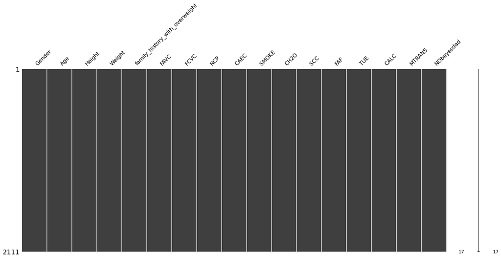

```python
mn.matrix(df)
```

```python
dup = df.duplicated()
len(df[dup])
```

```
24
```

There are no missing data found in the dataset. Thus, no imputations techniques are needed to be carried on the data. With respect to repeated data, there are a few duplicated instances. However, we can not know for sure if these are duplicated entries or two people with the same entries. Nevertheless, such number accounts for roughly 1% of the total data, and it will not affect the analysis.

Now, we will change the attributes names, so that their content get easier to understand:

```python
df.rename(columns = {'family_history_with_overweight': 'family_history', 'FAVC': 'high_caloric_food', 'FCVC': 'eating_vegetables', 'NCP': 'meal_number', 'CAEC':'eating_bet_meals', 'SMOKE': 'smoking', 'CH2O' : 'water_consumption', 'SCC' : 'monitoring_calories', 'FAF' : 'physical_activity', 'TUE': 'screen_time', 'CALC': 'alcohol_consumption', 'MTRANS': 'transportation', 'NObeyesdad': 'obesity_level'}, inplace=True)
df
```

|  | Gender | Age | Height | Weight | family_history | high_caloric_food | eating_vegetables | meal_number | eating_bet_meals | smoking | water_consumption | monitoring_calories | physical_activity | screen_time | alcohol_consumption | transportation | obesity_level |
| --- | --- | --- | --- | --- | --- | --- | --- | --- | --- | --- | --- | --- | --- | --- | --- | --- | --- |
| 0 | Female | 21.000000 | 1.620000 | 64.000000 | yes | no | 2.0 | 3.0 | Sometimes | no | 2.000000 | no | 0.000000 | 1.000000 | no | Public_Transportation | Normal_Weight |
| 1 | Female | 21.000000 | 1.520000 | 56.000000 | yes | no | 3.0 | 3.0 | Sometimes | yes | 3.000000 | yes | 3.000000 | 0.000000 | Sometimes | Public_Transportation | Normal_Weight |
| 2 | Male | 23.000000 | 1.800000 | 77.000000 | yes | no | 2.0 | 3.0 | Sometimes | no | 2.000000 | no | 2.000000 | 1.000000 | Frequently | Public_Transportation | Normal_Weight |
| 3 | Male | 27.000000 | 1.800000 | 87.000000 | no | no | 3.0 | 3.0 | Sometimes | no | 2.000000 | no | 2.000000 | 0.000000 | Frequently | Walking | Overweight_Level_I |
| 4 | Male | 22.000000 | 1.780000 | 89.800000 | no | no | 2.0 | 1.0 | Sometimes | no | 2.000000 | no | 0.000000 | 0.000000 | Sometimes | Public_Transportation | Overweight_Level_II |
| ... | ... | ... | ... | ... | ... | ... | ... | ... | ... | ... | ... | ... | ... | ... | ... | ... | ... |
| 2106 | Female | 20.976842 | 1.710730 | 131.408528 | yes | yes | 3.0 | 3.0 | Sometimes | no | 1.728139 | no | 1.676269 | 0.906247 | Sometimes | Public_Transportation | Obesity_Type_III |
| 2107 | Female | 21.982942 | 1.748584 | 133.742943 | yes | yes | 3.0 | 3.0 | Sometimes | no | 2.005130 | no | 1.341390 | 0.599270 | Sometimes | Public_Transportation | Obesity_Type_III |
| 2108 | Female | 22.524036 | 1.752206 | 133.689352 | yes | yes | 3.0 | 3.0 | Sometimes | no | 2.054193 | no | 1.414209 | 0.646288 | Sometimes | Public_Transportation | Obesity_Type_III |
| 2109 | Female | 24.361936 | 1.739450 | 133.346641 | yes | yes | 3.0 | 3.0 | Sometimes | no | 2.852339 | no | 1.139107 | 0.586035 | Sometimes | Public_Transportation | Obesity_Type_III |
| 2110 | Female | 23.664709 | 1.738836 | 133.472641 | yes | yes | 3.0 | 3.0 | Sometimes | no | 2.863513 | no | 1.026452 | 0.714137 | Sometimes | Public_Transportation | Obesity_Type_III |

2111 rows × 17 columns

Let us now consider the following entries: **Age**, **water_consumption**, **physical_activity** and **screen_time**. Their values should be integers, however some are displayed in float type. That is probably due to numerical noise, or garbage. We can round those values to the nearest integer, without loss of data meaning:

```python
df.Age=round(df.Age)
df.water_consumption=round(df.water_consumption)
df.physical_activity=round(df.physical_activity)
df.screen_time=round(df.screen_time)
df
```

|  | Gender | Age | Height | Weight | family_history | high_caloric_food | eating_vegetables | meal_number | eating_bet_meals | smoking | water_consumption | monitoring_calories | physical_activity | screen_time | alcohol_consumption | transportation | obesity_level |
| --- | --- | --- | --- | --- | --- | --- | --- | --- | --- | --- | --- | --- | --- | --- | --- | --- | --- |
| 0 | Female | 21.0 | 1.620000 | 64.000000 | yes | no | 2.0 | 3.0 | Sometimes | no | 2.0 | no | 0.0 | 1.0 | no | Public_Transportation | Normal_Weight |
| 1 | Female | 21.0 | 1.520000 | 56.000000 | yes | no | 3.0 | 3.0 | Sometimes | yes | 3.0 | yes | 3.0 | 0.0 | Sometimes | Public_Transportation | Normal_Weight |
| 2 | Male | 23.0 | 1.800000 | 77.000000 | yes | no | 2.0 | 3.0 | Sometimes | no | 2.0 | no | 2.0 | 1.0 | Frequently | Public_Transportation | Normal_Weight |
| 3 | Male | 27.0 | 1.800000 | 87.000000 | no | no | 3.0 | 3.0 | Sometimes | no | 2.0 | no | 2.0 | 0.0 | Frequently | Walking | Overweight_Level_I |
| 4 | Male | 22.0 | 1.780000 | 89.800000 | no | no | 2.0 | 1.0 | Sometimes | no | 2.0 | no | 0.0 | 0.0 | Sometimes | Public_Transportation | Overweight_Level_II |
| ... | ... | ... | ... | ... | ... | ... | ... | ... | ... | ... | ... | ... | ... | ... | ... | ... | ... |
| 2106 | Female | 21.0 | 1.710730 | 131.408528 | yes | yes | 3.0 | 3.0 | Sometimes | no | 2.0 | no | 2.0 | 1.0 | Sometimes | Public_Transportation | Obesity_Type_III |
| 2107 | Female | 22.0 | 1.748584 | 133.742943 | yes | yes | 3.0 | 3.0 | Sometimes | no | 2.0 | no | 1.0 | 1.0 | Sometimes | Public_Transportation | Obesity_Type_III |
| 2108 | Female | 23.0 | 1.752206 | 133.689352 | yes | yes | 3.0 | 3.0 | Sometimes | no | 2.0 | no | 1.0 | 1.0 | Sometimes | Public_Transportation | Obesity_Type_III |
| 2109 | Female | 24.0 | 1.739450 | 133.346641 | yes | yes | 3.0 | 3.0 | Sometimes | no | 3.0 | no | 1.0 | 1.0 | Sometimes | Public_Transportation | Obesity_Type_III |
| 2110 | Female | 24.0 | 1.738836 | 133.472641 | yes | yes | 3.0 | 3.0 | Sometimes | no | 3.0 | no | 1.0 | 1.0 | Sometimes | Public_Transportation | Obesity_Type_III |

2111 rows × 17 columns

Before proceeding to examine how categories are distributed, it is important to consider the columns which entries are related to frequency of a given habit. For some categories, options are already displayed as integers(ordinal), they are:

- Consuption of vegetables
- Number of main meals
- Water daily consuption
- Physical activity frequency
- Time using technological devices

However, for other entries, it is needed a conversion:

- Food consuption between meals
- Alcohol consuption
- Transport used
- Obesity level

For the obesity level, it used the Mass Body Index (MBI), $$MBI=\frac{weight}{height^2}$$

and results were classified using the following table:

| Mass Body Index | Obesity Level |
| --- | --- |
| < 18.5 | underweight |
| 18.5 - 24.9 | normal |
| 25.0 - 29.9 | overweight |
| 30.0 - 34.9 | obesity I |
| 35.0 - 39.9 | obesity II |
| > 40.0 | obesity III |

Here, it is worth mention that, in the dataset, there are another entry **Overweight II** , and the article does not insert it in any MBI range. However, we will consider that someone classified with Overweight II has a MBI value greater than people classified as Overweight and smaller than the ones classified in Obesity I.

Aditionally, the categories which entries are yes/no must also be converted (binary) and we establish the following convention:

- Yes = 1
- No = 0

#### Note:

For frequency related categories, the values were converted to integers as follows: lower frequency entries were related to smaller integers (starting in 0, which means 'No' entry) and higher frequency entries, to the larger integers. However, the **eating_vegetables** category, which have its entry already displayed in ordinals, display the lowest frequency as a 1, instead of 0. In order to make our analysis more user-friendly, we will subtract 1 from each entry, in order to shift it for the used scale.

```python
frequency=['no','Sometimes','Frequently','Always']
interval=range(4)
yn=['no','yes']
binary=range(2)
df.family_history.replace(to_replace=yn[:],
                          value=binary,
                          inplace=True)
df.high_caloric_food.replace(to_replace=yn[:],
               value=binary,
               inplace=True)
df.smoking.replace(to_replace=yn[:],
                value=binary,
                inplace=True)
df.monitoring_calories.replace(to_replace=yn[:],
              value=binary,
              inplace=True)
df.eating_bet_meals.replace(to_replace=frequency[:],
               value=interval,
               inplace=True)
df.alcohol_consumption.replace(to_replace=frequency[:],
               value=interval,
               inplace=True)
df.transportation.replace(to_replace=['Walking','Bike','Public_Transportation','Motorbike','Automobile'],
                 value=range(5),
                 inplace=True)
df.eating_vegetables=df.eating_vegetables[:]-1

df
```

|  | Gender | Age | Height | Weight | family_history | high_caloric_food | eating_vegetables | meal_number | eating_bet_meals | smoking | water_consumption | monitoring_calories | physical_activity | screen_time | alcohol_consumption | transportation | obesity_level |
| --- | --- | --- | --- | --- | --- | --- | --- | --- | --- | --- | --- | --- | --- | --- | --- | --- | --- |
| 0 | Female | 21.0 | 1.620000 | 64.000000 | 1 | 0 | 1.0 | 3.0 | 1 | 0 | 2.0 | 0 | 0.0 | 1.0 | 0 | 2 | Normal_Weight |
| 1 | Female | 21.0 | 1.520000 | 56.000000 | 1 | 0 | 2.0 | 3.0 | 1 | 1 | 3.0 | 1 | 3.0 | 0.0 | 1 | 2 | Normal_Weight |
| 2 | Male | 23.0 | 1.800000 | 77.000000 | 1 | 0 | 1.0 | 3.0 | 1 | 0 | 2.0 | 0 | 2.0 | 1.0 | 2 | 2 | Normal_Weight |
| 3 | Male | 27.0 | 1.800000 | 87.000000 | 0 | 0 | 2.0 | 3.0 | 1 | 0 | 2.0 | 0 | 2.0 | 0.0 | 2 | 0 | Overweight_Level_I |
| 4 | Male | 22.0 | 1.780000 | 89.800000 | 0 | 0 | 1.0 | 1.0 | 1 | 0 | 2.0 | 0 | 0.0 | 0.0 | 1 | 2 | Overweight_Level_II |
| ... | ... | ... | ... | ... | ... | ... | ... | ... | ... | ... | ... | ... | ... | ... | ... | ... | ... |
| 2106 | Female | 21.0 | 1.710730 | 131.408528 | 1 | 1 | 2.0 | 3.0 | 1 | 0 | 2.0 | 0 | 2.0 | 1.0 | 1 | 2 | Obesity_Type_III |
| 2107 | Female | 22.0 | 1.748584 | 133.742943 | 1 | 1 | 2.0 | 3.0 | 1 | 0 | 2.0 | 0 | 1.0 | 1.0 | 1 | 2 | Obesity_Type_III |
| 2108 | Female | 23.0 | 1.752206 | 133.689352 | 1 | 1 | 2.0 | 3.0 | 1 | 0 | 2.0 | 0 | 1.0 | 1.0 | 1 | 2 | Obesity_Type_III |
| 2109 | Female | 24.0 | 1.739450 | 133.346641 | 1 | 1 | 2.0 | 3.0 | 1 | 0 | 3.0 | 0 | 1.0 | 1.0 | 1 | 2 | Obesity_Type_III |
| 2110 | Female | 24.0 | 1.738836 | 133.472641 | 1 | 1 | 2.0 | 3.0 | 1 | 0 | 3.0 | 0 | 1.0 | 1.0 | 1 | 2 | Obesity_Type_III |

2111 rows × 17 columns

```python
df.info()
```

```
<class 'pandas.core.frame.DataFrame'>
RangeIndex: 2111 entries, 0 to 2110
Data columns (total 17 columns):
 #   Column               Non-Null Count  Dtype
---  ------               --------------  -----
 0   Gender               2111 non-null   object
 1   Age                  2111 non-null   float64
 2   Height               2111 non-null   float64
 3   Weight               2111 non-null   float64
 4   family_history       2111 non-null   int64
 5   high_caloric_food    2111 non-null   int64
 6   eating_vegetables    2111 non-null   float64
 7   meal_number          2111 non-null   float64
 8   eating_bet_meals     2111 non-null   int64
 9   smoking              2111 non-null   int64
 10  water_consumption    2111 non-null   float64
 11  monitoring_calories  2111 non-null   int64
 12  physical_activity    2111 non-null   float64
 13  screen_time          2111 non-null   float64
 14  alcohol_consumption  2111 non-null   int64
 15  transportation       2111 non-null   int64
 16  obesity_level        2111 non-null   object
dtypes: float64(8), int64(7), object(2)
memory usage: 280.5+ KB
```

Finally, it is also possible to remove the categories **Height** and **Weight**, once these were used to calculate the BMI which, on its turn, was already employed to display the Obesity Levels:

```python
del df['Height']
del df['Weight']
df
```

|  | Gender | Age | family_history | high_caloric_food | eating_vegetables | meal_number | eating_bet_meals | smoking | water_consumption | monitoring_calories | physical_activity | screen_time | alcohol_consumption | transportation | obesity_level |
| --- | --- | --- | --- | --- | --- | --- | --- | --- | --- | --- | --- | --- | --- | --- | --- |
| 0 | Female | 21.0 | 1 | 0 | 1.0 | 3.0 | 1 | 0 | 2.0 | 0 | 0.0 | 1.0 | 0 | 2 | Normal_Weight |
| 1 | Female | 21.0 | 1 | 0 | 2.0 | 3.0 | 1 | 1 | 3.0 | 1 | 3.0 | 0.0 | 1 | 2 | Normal_Weight |
| 2 | Male | 23.0 | 1 | 0 | 1.0 | 3.0 | 1 | 0 | 2.0 | 0 | 2.0 | 1.0 | 2 | 2 | Normal_Weight |
| 3 | Male | 27.0 | 0 | 0 | 2.0 | 3.0 | 1 | 0 | 2.0 | 0 | 2.0 | 0.0 | 2 | 0 | Overweight_Level_I |
| 4 | Male | 22.0 | 0 | 0 | 1.0 | 1.0 | 1 | 0 | 2.0 | 0 | 0.0 | 0.0 | 1 | 2 | Overweight_Level_II |
| ... | ... | ... | ... | ... | ... | ... | ... | ... | ... | ... | ... | ... | ... | ... | ... |
| 2106 | Female | 21.0 | 1 | 1 | 2.0 | 3.0 | 1 | 0 | 2.0 | 0 | 2.0 | 1.0 | 1 | 2 | Obesity_Type_III |
| 2107 | Female | 22.0 | 1 | 1 | 2.0 | 3.0 | 1 | 0 | 2.0 | 0 | 1.0 | 1.0 | 1 | 2 | Obesity_Type_III |
| 2108 | Female | 23.0 | 1 | 1 | 2.0 | 3.0 | 1 | 0 | 2.0 | 0 | 1.0 | 1.0 | 1 | 2 | Obesity_Type_III |
| 2109 | Female | 24.0 | 1 | 1 | 2.0 | 3.0 | 1 | 0 | 3.0 | 0 | 1.0 | 1.0 | 1 | 2 | Obesity_Type_III |
| 2110 | Female | 24.0 | 1 | 1 | 2.0 | 3.0 | 1 | 0 | 3.0 | 0 | 1.0 | 1.0 | 1 | 2 | Obesity_Type_III |

2111 rows × 15 columns

### Exploring Data

Having done the data pre-processing, let us now explore their entries. Initially, we will split it into Men and Women:

```python
df_grouped=df.groupby(by='Gender')
for val,grp in df_grouped:
    print('There are',len(grp),val,'in this research.')
```

```
There are 1043 Female in this research.
There are 1068 Male in this research.
```

Now, we proceed in examining how remaining categories are distributed:

```python
print('Number and percentual of people who present a familiar historic with overweight:')
print(df_grouped['family_history'].sum())
print(df_grouped.family_history.sum()/df_grouped.family_history.count())
print('-----------------------------------------------------------------------')
print('Number of people who frequently consume high caloric food:')
print(df_grouped['high_caloric_food'].sum())
print(df_grouped.high_caloric_food.sum()/df_grouped.high_caloric_food.count())
print('-----------------------------------------------------------------------')
print('Number of people who smoke:')
print(df_grouped['smoking'].sum())
print(df_grouped.smoking.sum()/df_grouped.smoking.count())
print()
```

```
Number and percentual of people who present a familiar historic with overweight:
Gender
Female    811
Male      915
Name: family_history, dtype: int64
Gender
Female    0.777565
Male      0.856742
Name: family_history, dtype: float64
-----------------------------------------------------------------------
Number of people who frequently consume high caloric food:
Gender
Female    900
Male      966
Name: high_caloric_food, dtype: int64
Gender
Female    0.862895
Male      0.904494
Name: high_caloric_food, dtype: float64
-----------------------------------------------------------------------
Number of people who smoke:
Gender
Female    15
Male      29
Name: smoking, dtype: int64
Gender
Female    0.014382
Male      0.027154
Name: smoking, dtype: float64
```

The previously displayed data show that most of the people in the research have familiar historic with overweight and consume high caloric food. However, very few of them have the habit of smoking. These findings, specially the smoking habit, might be due to a failure in the sampling process.

We might probably drop the Smoke column, since we have almost zero smokers and the smoking habit seems not to be of relevance in the obesity level for this research:

```python
del df['smoking']
df
```

|  | Gender | Age | family_history | high_caloric_food | eating_vegetables | meal_number | eating_bet_meals | water_consumption | monitoring_calories | physical_activity | screen_time | alcohol_consumption | transportation | obesity_level |
| --- | --- | --- | --- | --- | --- | --- | --- | --- | --- | --- | --- | --- | --- | --- |
| 0 | Female | 21.0 | 1 | 0 | 1.0 | 3.0 | 1 | 2.0 | 0 | 0.0 | 1.0 | 0 | 2 | Normal_Weight |
| 1 | Female | 21.0 | 1 | 0 | 2.0 | 3.0 | 1 | 3.0 | 1 | 3.0 | 0.0 | 1 | 2 | Normal_Weight |
| 2 | Male | 23.0 | 1 | 0 | 1.0 | 3.0 | 1 | 2.0 | 0 | 2.0 | 1.0 | 2 | 2 | Normal_Weight |
| 3 | Male | 27.0 | 0 | 0 | 2.0 | 3.0 | 1 | 2.0 | 0 | 2.0 | 0.0 | 2 | 0 | Overweight_Level_I |
| 4 | Male | 22.0 | 0 | 0 | 1.0 | 1.0 | 1 | 2.0 | 0 | 0.0 | 0.0 | 1 | 2 | Overweight_Level_II |
| ... | ... | ... | ... | ... | ... | ... | ... | ... | ... | ... | ... | ... | ... | ... |
| 2106 | Female | 21.0 | 1 | 1 | 2.0 | 3.0 | 1 | 2.0 | 0 | 2.0 | 1.0 | 1 | 2 | Obesity_Type_III |
| 2107 | Female | 22.0 | 1 | 1 | 2.0 | 3.0 | 1 | 2.0 | 0 | 1.0 | 1.0 | 1 | 2 | Obesity_Type_III |
| 2108 | Female | 23.0 | 1 | 1 | 2.0 | 3.0 | 1 | 2.0 | 0 | 1.0 | 1.0 | 1 | 2 | Obesity_Type_III |
| 2109 | Female | 24.0 | 1 | 1 | 2.0 | 3.0 | 1 | 3.0 | 0 | 1.0 | 1.0 | 1 | 2 | Obesity_Type_III |
| 2110 | Female | 24.0 | 1 | 1 | 2.0 | 3.0 | 1 | 3.0 | 0 | 1.0 | 1.0 | 1 | 2 | Obesity_Type_III |

2111 rows × 14 columns

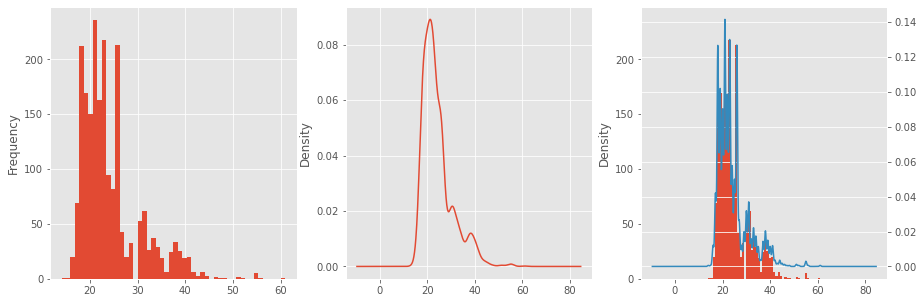

```python
#Exploring the age range of the sample
plt.style.use('ggplot')
fig = plt.figure(figsize=(15,5))

plt.subplot(1,3,1)
df.Age.plot.hist(bins=50)

plt.subplot(1,3,2)
df.Age.plot.kde(bw_method=0.2)

plt.subplot(1,3,3)
df.Age.plot.hist(bins=50)
df.Age.plot.kde(bw_method=0.05, secondary_y=True)

plt.show()
```

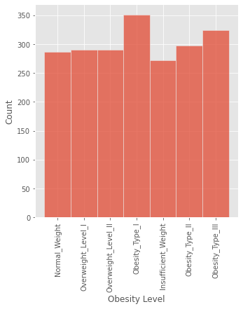

```python
# Counting the number of instances in each obesity level
sns.displot(df['obesity_level'])
plt.xticks(rotation=90)
plt.xlabel('Obesity Level')
plt.show()
```

### Question 1: How does Gender affect the level of obesity?

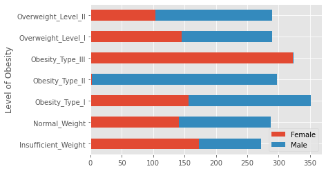

```python
gender_within_group = pd.crosstab(df.obesity_level, df.Gender)
ax = gender_within_group.plot(kind = 'barh', stacked =True)
plt.legend(loc=0)
plt.ylabel('Level of Obesity')
plt.show()
```

Group by gender to know if the differences due to the difference in distrubtion and not sampling problem:

```python
df_gender = df.groupby(by = ['Gender'])
print (df_gender.Gender.count())
```

```
Gender
Female    1043
Male      1068
Name: Gender, dtype: int64
```

As previously observed, there are nearly similar number of males and females in the group sample. This reflects that the difference in the distribution of the obesity level might be due to differences of gender and not a sampling problem. Males tend to occupy nearly all obesity type II, however females tend to occupy nearly all obesity level III.

### Question 2: How does life style affect the level of obesity?

#### Question 2.1 : How does high caloric food intake affect the level of obesity?

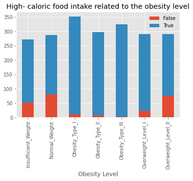

```python
caloric = pd.crosstab(df.obesity_level, df.high_caloric_food.astype(bool))

caloric.plot(kind='bar', stacked =True)
plt.xlabel('Obesity Level')
plt.title('High- caloric food intake related to the obesity level')
plt.legend(loc='best')
plt.show()
```

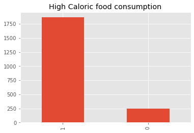

```python
plt.figure()
plt.title('High Caloric food consumption')
df.high_caloric_food.value_counts().plot(kind = 'bar')
```

From the graph above, we observe that all categories of obesity level (including the insufficient weight entry) present a higher amount of **high caloric food consumption** . However, there is no equal distribution of the sample between those have high-caloric intake and those don't. That is why it is difficult to determine the effect oh high caloric food intake based on the sample. Moreover, it is worth mention that, as oposite to other entries, in this category, there are just two possible answers, yes or no, and it is likely that most of people answered yes, though they might have different frequencies of high caloric food consumption.

#### Question 2.2 : How does the frequency of eating vegetables affect the level of obesity?

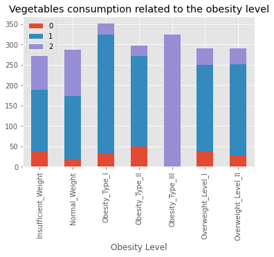

```python
veg = pd.crosstab(df.obesity_level, df.eating_vegetables.astype(int))

veg.plot(kind='bar', stacked =True)
plt.xlabel('Obesity Level')
plt.title('Vegetables consumption related to the obesity level')
plt.legend(loc='best')
plt.show()
```

Considering levels up to Obesity II, vegetables consumption has a small correlation with obesity. Overweight and Obesity I and II entries tend to show a smaller frequency in vegetables consumption. For Obesity III, surprisingly 100% of the entries show the highest frequency in vegetables consumption, this is probably a sampling error.

#### Question 2.3 : How does the number of main meals affect the level of obesity?

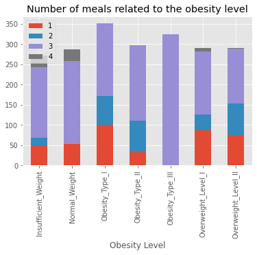

```python
meal = pd.crosstab(df.obesity_level, df.meal_number.astype(int))

meal.plot(kind='bar', stacked =True)
plt.xlabel('Obesity Level')
plt.title('Number of meals related to the obesity level')
plt.legend(loc='best')
plt.show()
```

Similarly to the previous graph, the number of main meals does not seem to correlate to obesity.

#### Question 2.4 : How eating between meals affect the level of obesity?

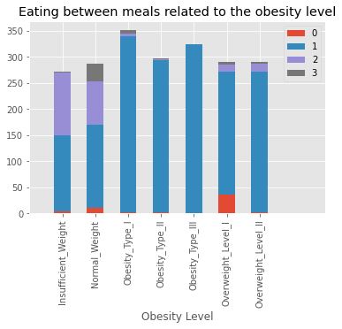

```python
eat = pd.crosstab(df.obesity_level, df.eating_bet_meals.astype(int))

eat.plot(kind='bar', stacked =True)
plt.xlabel('Obesity Level')
plt.title('Eating between meals related to the obesity level')
plt.legend(loc='best')
plt.xlim(-1,8)
plt.show()
```

#### Question 2.5 : How does screen time affect the level of obesity?

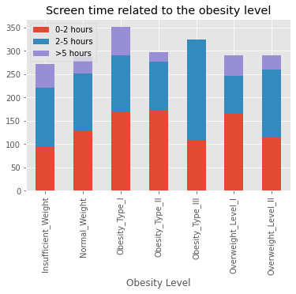

```python
screen = pd.crosstab(df.obesity_level, df.screen_time)#.astype(bool))

screen.plot(kind='bar', stacked =True)
plt.xlabel('Obesity Level')
plt.title('Screen time related to the obesity level')
plt.legend(['0-2 hours', '2-5 hours', '>5 hours'],loc='best')
plt.show()
```

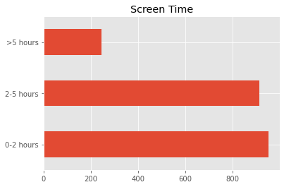

```python
df.screen_time.replace(to_replace=[0, 1, 2], value =['0-2 hours', '2-5 hours', '>5 hours'], inplace=True)


plt.figure()
plt.title('Screen Time')
df.screen_time.value_counts().plot(kind = 'barh')
```

The screen time does not seem to affect one's obesity level, since the results tend to be similar for all levels.

#### Question 2.6 : How does the water consumption effect the obesity level?

```python
df["water_consumption"]=df["water_consumption"].round(0).astype(int)
```

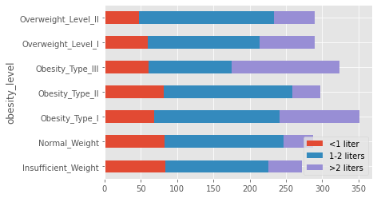

```python
water = pd.crosstab(
                       [df['obesity_level']],
                       df.water_consumption.astype(int))

water.plot(kind='barh', stacked=True)
plt.legend(['<1 liter', '1-2 liters', '>2 liters'],loc='best')
plt.show()
```

Attributes such as meal number and high calorie food consumption cannot be taken as the factors which determine the obesity level correctly according to the above graphs because majority of collected data represents one side.

### Question 3: How does family history affect the level of obesity?

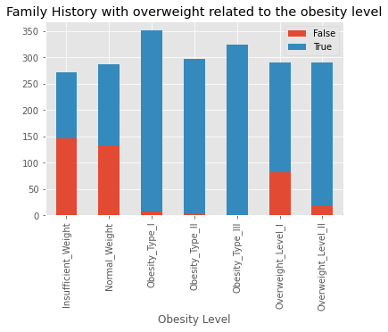

```python
family_history = pd.crosstab(df.obesity_level, df.family_history.astype(bool))
family_history.plot(kind='bar', stacked = True)
plt.xlabel('Obesity Level')
plt.title('Family History with overweight related to the obesity level')
plt.legend(loc='best')
plt.show()
```

Family history with overweight was found to be an important factor for people to suffer from high level of obesity. People with normal weight are not suffering with family history with overweight compared to those suffering from obesity or overweight.

### Question 4 : How does age affect the obesity level?

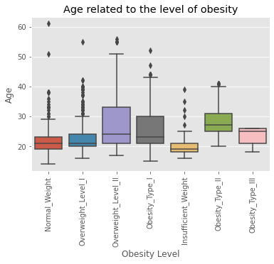

```python
sns.boxplot(x='obesity_level', y ='Age', data=df)
plt.xlabel('Obesity Level')
plt.ylabel('Age')
plt.title('Age related to the level of obesity')
plt.xticks(rotation=90)
plt.show()
```

The previous graph shows a higher number of outliers. This is the reason why grouping based on age was performed to get a better representation for the effect of age on the level of obesity,

```python
df['Age_range'] = pd.cut(df['Age'],
                                 [13,17,30,55],
                                 labels=['teen','young adult','adult']) # this creates a new variable
df.Age_range.describe()
```

```
count            2109
unique              3
top       young adult
freq             1687
Name: Age_range, dtype: object
```

Age and Gender relationship to the obesity level

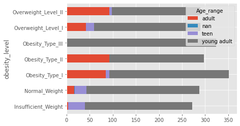

```python
age = pd.crosstab(df.obesity_level, df.Age_range.astype(str))

age.plot(kind='barh', stacked=True)
plt.show()
```

Most of the sample are within the age range of 17-30 (young adult). That is why this identified class ocuppies most of the obesity classes.

### Question 5: How does transport relates with obesity?

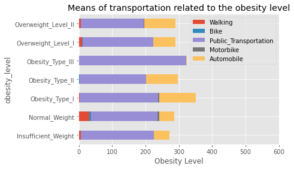

```python
transport = pd.crosstab(df['obesity_level'], df.transportation.astype(str))

transport.plot(kind='barh', stacked =True)
plt.xlabel('Obesity Level')
plt.title('Means of transportation related to the obesity level')
plt.xlim([-1,600])
plt.legend(['Walking','Bike','Public_Transportation','Motorbike','Automobile'],loc=0)
plt.show()
```

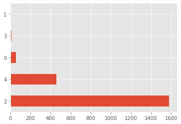

```python
plt.figure()
plt.title = ('Transportation')
plt.ylabel=['Walking','Bike','Public_Transportation','Motorbike','Automobile']
plt.legend(['Walking','Bike','Public_Transportation','Motorbike','Automobile'],loc=0)
df['transportation'].value_counts().plot(kind='barh')
```

We observe that public transport is the majority in all obesity levels. Therefore, it can be either a sampling error or means of transportation are not entirely correlated with obesity.

### Question 6: How are the different features correlated with each other?

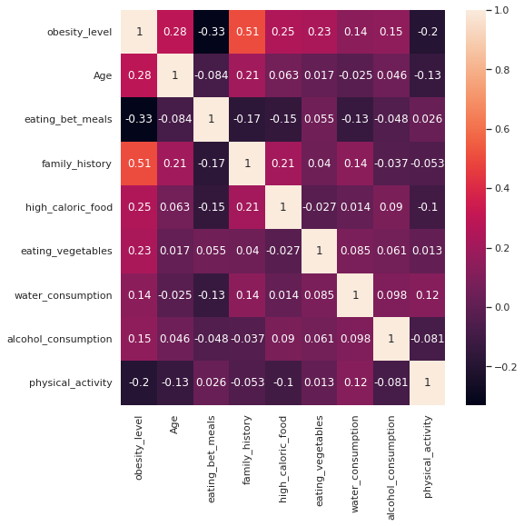

```python
df.obesity_level.replace(to_replace=['Insufficient_Weight', 'Normal_Weight', 'Overweight_Level_I', 'Overweight_Level_II', 'Obesity_Type_I', 'Obesity_Type_II', 'Obesity_Type_III'], value = [1, 2, 3, 4, 5, 6, 7], inplace=True)

cmap = sns.set(style="darkgrid")
var = ['obesity_level', 'Age', 'Gender', 'eating_bet_meals', 'family_history','high_caloric_food', 'eating_vegetables', 'water_consumption', 'screen_time', 'alcohol_consumption', 'physical_activity']
f, ax = plt.subplots(figsize=(8, 8))
sns.heatmap(df[var].corr(), cmap=cmap, annot=True)
```

### Dimensionality reduction using Uniform Manifold Approximation and Projection (UMAP)

Dimensionality reduction is often employed when one is dealing with a large dataset. UMAP technique starts with a higher dimensional graph and then cluster similar entries in order to provide a lower dimensional version of it, with minimal loss of information.

```python
df1 = df.drop(["Gender","screen_time","Age_range","eating_vegetables","monitoring_calories","transportation","alcohol_consumption",
              "eating_bet_meals","high_caloric_food"],axis=1)
```

```python
df1.head(5)
```

|  | Age | family_history | meal_number | water_consumption | physical_activity | obesity_level |
| --- | --- | --- | --- | --- | --- | --- |
| 0 | 21.0 | 1 | 3.0 | 2 | 0.0 | 2 |
| 1 | 21.0 | 1 | 3.0 | 3 | 3.0 | 2 |
| 2 | 23.0 | 1 | 3.0 | 2 | 2.0 | 2 |
| 3 | 27.0 | 0 | 3.0 | 2 | 2.0 | 3 |
| 4 | 22.0 | 0 | 1.0 | 2 | 0.0 | 4 |

[output not shown]

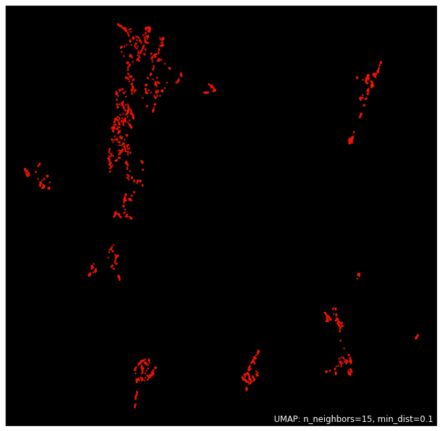

```python
import umap
import umap.plot
mapper = umap.UMAP().fit(df1)
umap.plot.points(mapper, theme='fire')
```

This is the UMAP plot with similar categories clustered. As previously observed, our data is less correlated.